# Práctica 1: Descarga de datos climáticos para una región concreta, basada en bucles, mediante Rstudio.

En esta práctica se aprenderá a descargar datos de manera eficaz. La forma tradicional, hasta ahora, ha sido la descarga de datos de manera manual. Sin embargo, existen maneras mucho más eficaces. Además, para evitar la descarga de datos innecesarios se guardarán solo los datos del area de estudio que nos interese.

Cargar las librerías que se utilizarán

```r
library(raster)
library(stringr)
```

Datos climáticos  
Existen multitud de datos climáticos. En este seminario se utilizarán los datos de Climatologies at high resolution for the earth’s land surface areas (CHELSA) https://chelsa-climate.org/timeseries/

[figure not shown]

[figure not shown]

Cargamos el archivo`.txt` mediante la función `readLines`.

```r
download_chelsa <- readLines("C:/GITHUB_REP/seminario_biogeografia_MNCN/download_chelsa.txt")
```

Seleccionamos la variable que queremos descargar.

```r
download_chelsa <- download_chelsa[grepl("tasmin", download_chelsa)]
```

```r
download_chelsa <- download_chelsa[grepl("1980|2018", download_chelsa)]
```

Preparar el área de estudio para extraer los datos solo de dicha región. En este caso se utilizará el archivo correspondiente a la comunidad autónoma de Aragón.

```r
Aragon <- raster::shapefile("D:/SEMINARIO_BIOGEOGRAFIA/VECTORIAL/ARAGON/Aragon.shp")
```

Ejemplo para un solo raster Descargar archivo mediante la función `download.file`. En este caso solo descargamos el primer dato de `download_chelsa` y se llamará `raster_temporal.tif`.  
`dest`: Directorio donde se descargará el raster

```r
download.file(download_chelsa[1],
              dest = "D:/SEMINARIO_BIOGEOGRAFIA/raster_temporal.tif",
              mode = "wb")
```

Cargar el raster previamente descargado.

```r
raster <- raster("D:/SEMINARIO_BIOGEOGRAFIA/raster_temporal.tif")
```

Cortar el raster con el area de estudio, en este caso Aragón.

```r
raster<- crop(raster, Aragon)
raster_Aragon <- mask(raster, Aragon)
```

Visualuzar el raster generado.

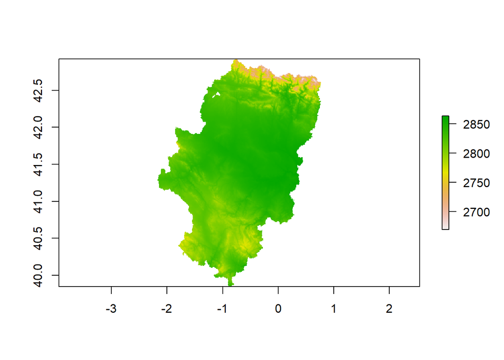

```r
plot(raster_Aragon)
```

Modificar las unidades de la temperatura (*ºK x 10 = ºC*).

```r
raster_Aragon <- raster_Aragon / 10
raster_Aragon <- raster_Aragon - 273.15
```

Visualuzar el raster generado.

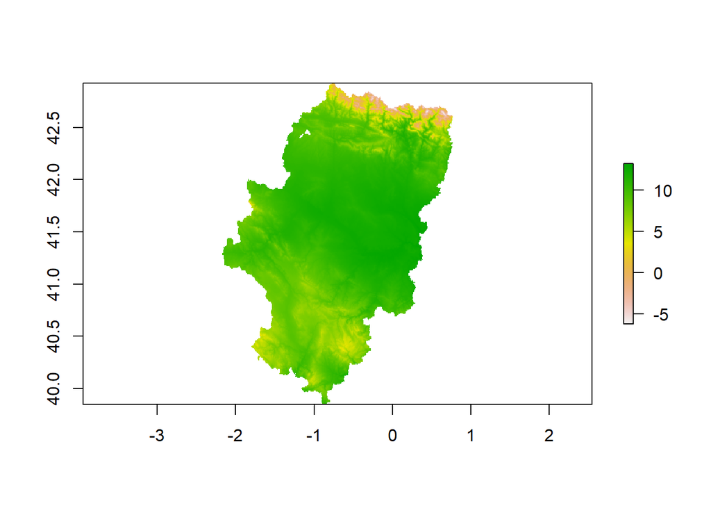

```r
plot(raster_Aragon)
```

Exportar el raster con la información del archivo descargado.  
Ver la información que queremos conservar.

```r
download_chelsa[1]
```

```
## [1] "https://os.zhdk.cloud.switch.ch/envicloud/chelsa/chelsa_V2/GLOBAL/monthly/tasmin/CHELSA_tasmin_01_1980_V.2.1.tif "
```

https://os.zhdk.cloud.switch.ch/envicloud/chelsa/chelsa_V2/GLOBAL/monthly/tasmin/CHELSA_tasmin_01_1980_V.2.1.tif  
En nuestro caso queremos conservar la información de la variable `tmin` mes `01` y año `1980`.  
Esta información corresponde a lo que viene después de `tasmin_` y antes de `_V.2`.  
Para ello utilizamos la función `gregexpr` crea una lista donde se indica:  
- La posición desde la que selecciona los datos.  
- El numero de caracteres que coinciden.

```r
gregexpr("tasmin_", download_chelsa[1])
```

```
## [[1]]
## [1] 89
## attr(,"match.length")
## [1] 7
## attr(,"index.type")
## [1] "chars"
## attr(,"useBytes")
## [1] TRUE
```

La función `unlist` selecciona el primer elemento de la lista creada por la función `gregexpr`.  
De esta manera se obtiene la posición.  
Se puede modificar `+`o `-` la posición. Como no queremos la _ de _V.2 indicamos que sea hasta una posición aterior `-1`.

```r
unlist(gregexpr("tasmin_", download_chelsa[1]))
```

```
## [1] 89
```

```r
unlist(gregexpr("_V.2", download_chelsa[1])) - 1
```

```
## [1] 102
```

Conociendo las posiciones entre las cuales queremos seleccionar, se utiliza la función `str_sub` de paquete `stringr`.

```r
str_sub(download_chelsa[1],
        unlist(gregexpr("tasmin_", download_chelsa[1])),
        unlist(gregexpr("_V.2", download_chelsa[1])) - 1)
```

```
## [1] "tasmin_01_1980"
```

Ahora solo falta unir este nombre al directorio donde queremos guardarlo.  
La función `paste0`es una de las mas útiles para unir cadenas de texto.

```r
a = c("La función ", "paste0 ")
b = c("permite")
paste0(a[1], a[2], b," unificar ", "cadenas de texto")
```

```
## [1] "La función paste0 permite unificar cadenas de texto"
```

```r
paste0(
  "D:/SEMINARIO_BIOGEOGRAFIA/RASTER/TMIN",
  str_sub(download_chelsa[1],
        unlist(gregexpr("tasmin_", download_chelsa[1])),
        unlist(gregexpr("_V.2", download_chelsa[1])) - 1),
  ".tif")
```

```
## [1] "D:/SEMINARIO_BIOGEOGRAFIA/RASTER/TMINtasmin_01_1980.tif"
```

Teniendo el directorio acorde al archivo se introduce como directorio para guardar el raster.

```r
writeRaster(raster_Aragon,
              paste0("D:/SEMINARIO_BIOGEOGRAFIA/",
                     str_sub(download_chelsa[1],
                             unlist(gregexpr("tasmin_", download_chelsa[1])),
                             unlist(gregexpr("_V.2", download_chelsa[1])) - 1),
                     ".tif"))
```

Ahora que sabemos realizar la descarga y el posterior recorte con el área de estudio simplemente haría falta indicar que itere sobre todos los elementos de `download_chelsa`.  
Para ello vamos a utilizar un bucle. Los bucles se utilizan en la programación para repetir un bloque específico de código.  
**Un ejemplo sencillo.**  
Para un numero (1 y 2 en este caso), muestra el resultado de esos números + 2.

```r
for(numero in c(1, 2)){
  print(numero + 2)
}
```

```
## [1] 3
## [1] 4
```

Aplicaremos esta lógica para la descarga de los datos climáticos.

```r
for (i in 1:length(download_chelsa)){
  download.file(download_chelsa[i],
              dest = "D:/SEMINARIO_BIOGEOGRAFIA/raster_temporal.tif",
              mode = "wb")
  raster <- raster("D:/SEMINARIO_BIOGEOGRAFIA/raster_temporal.tif")
  raster<- crop(raster, Aragon)
  raster_Aragon <- mask(raster, Aragon)
  raster_Aragon <- raster_Aragon / 10
  raster_Aragon <- raster_Aragon - 273.15

  paste0(
  "D:/SEMINARIO_BIOGEOGRAFIA/RASTER/TMIN/",
  str_sub(download_chelsa[i],
        unlist(gregexpr("tasmin_", download_chelsa[i])),
        unlist(gregexpr("_V.2", download_chelsa[i])) - 1),
  ".tif")
}
```

A continuación se muestra el código completo para la descarga de datos mediante bucles.

```r
library(raster)
library(stringr)
download_chelsa <- readLines("C:/GITHUB_REP/seminario_biogeografia_MNCN/download_chelsa.txt")
download_chelsa <- download_chelsa[grepl("1980|2018", download_chelsa)]

Aragon <- raster::shapefile("D:/SEMINARIO_BIOGEOGRAFIA/VECTORIAL/ARAGON/Aragon.shp")

# Temperatura mínima
download_chelsa_tasmin <- download_chelsa[grepl("tasmin", download_chelsa)]

for (i in 1:length(download_chelsa_tasmin)){
  download.file(download_chelsa_tasmin[i],
                dest = "D:/SEMINARIO_BIOGEOGRAFIA/raster_temporal.tif",
                mode = "wb")
  raster <- raster("D:/SEMINARIO_BIOGEOGRAFIA/raster_temporal.tif")
  raster<- crop(raster, Aragon)
  raster_Aragon <- mask(raster, Aragon)
  raster_Aragon <- raster_Aragon / 10
  raster_Aragon <- raster_Aragon - 273.15

  writeRaster(raster_Aragon,
              paste0(
                "D:/SEMINARIO_BIOGEOGRAFIA/RASTER/TEMPERATURA_MINIMA/",
                str_sub(
                  download_chelsa_tasmin[i],
                  unlist(gregexpr("tasmin_", download_chelsa_tasmin[i])),
                  unlist(gregexpr("_V.2", download_chelsa_tasmin[i])) - 1),
                ".tif"))
}

# Precipitación
download_chelsa_pr <- download_chelsa[grepl("pr", download_chelsa)]

for (i in 1:length(download_chelsa_pr)){
  download.file(download_chelsa_pr[i],
                dest = "D:/SEMINARIO_BIOGEOGRAFIA/raster_temporal.tif",
                mode = "wb")
  raster <- raster("D:/SEMINARIO_BIOGEOGRAFIA/raster_temporal.tif")
  raster<- crop(raster, Aragon)
  raster_Aragon <- mask(raster, Aragon)
  raster_Aragon <- raster_Aragon / 10

  writeRaster(raster_Aragon,
              paste0(
                "D:/SEMINARIO_BIOGEOGRAFIA/RASTER/PRECIPITACION/",
                str_sub(
                  download_chelsa_pr[i],
                  unlist(gregexpr("pr_", download_chelsa_pr[i])),
                  unlist(gregexpr("_V.2", download_chelsa_pr[i])) - 1),
                ".tif"))
}
```

# Ejercicio práctica 1

Descargar la capa de temperatura máxima de enero de 2012 para la comunidad autónoma de Aragón y guardarla como `tmax_aragon_1_2012.tif`, en una nueva carpeta llamada `Practica_1`. Ejemplo (modificar XXX):

```r
library(raster)
library(stringr)
download_chelsa <- readLines("C:/GITHUB_REP/seminario_biogeografia_MNCN/XXX.txt")
download_chelsa <- download_chelsa[grepl("XXX", download_chelsa)]

Aragon <- raster::shapefile("D:/SEMINARIO_BIOGEOGRAFIA/VECTORIAL/Aragon.shp")
download.file(XXX,
                dest = "D:/SEMINARIO_BIOGEOGRAFIA/raster_temporal.tif",
                mode = "wb")
  raster <- raster("D:/SEMINARIO_BIOGEOGRAFIA/raster_temporal.tif")
  raster <- crop(XXX, XXX)
  raster_Aragon <- mask(XXX, XXX)
  raster_Aragon <- raster_Aragon / 10
  raster_Aragon <- raster_Aragon - 273.15

  writeRaster(raster_Aragon, "D:/SEMINARIO_BIOGEOGRAFIA/RESULTADOS/PRACTICA_1/XXX")
```

Solución:

```r
library(raster)
library(stringr)
# Descargar un nuevo .txt de la temperatura máxima
download_chelsa <- readLines("C:/GITHUB_REP/seminario_biogeografia_MNCN/download_chelsa_2.txt")
download_chelsa <- download_chelsa[grepl("01_2012", download_chelsa)]

Aragon <- raster::shapefile("D:/SEMINARIO_BIOGEOGRAFIA/VECTORIAL/ARAGON/Aragon.shp")
download.file(download_chelsa,
                dest = "D:/SEMINARIO_BIOGEOGRAFIA/raster_temporal.tif",
                mode = "wb")
  raster <- raster("D:/SEMINARIO_BIOGEOGRAFIA/raster_temporal.tif")
  raster <- crop(raster, Aragon)
  raster_Aragon <- mask(raster, Aragon)
  raster_Aragon <- raster_Aragon / 10
  raster_Aragon <- raster_Aragon - 273.15

  writeRaster(raster_Aragon, "D:/SEMINARIO_BIOGEOGRAFIA/RESULTADOS/PRACTICA_1/tmax_aragon_1_2012.tif")
```